# Spendy: Customer Loyalty Analysis

Spendy is a Buy Now Pay Later platform and understanding which customers are genuinely loyal to the platform, not just frequent buyers at a single merchant, is key to making smarter marketing decisions.

This notebook builds a data-driven definition of customer loyalty from the ground up, applies it to track how the loyal customer base grows over time, and then trains a model to predict whether a brand new customer will become loyal based on just their first two months of activity.

**Sections:**

1. Data Loading & Exploration
2. Defining a Loyal Customer (component by component)
3. Applying the Loyalty Definition & Tracking Over Time
4. ML Model: Predicting Loyalty from First 2 Months
5. Future Improvements
6. Conclusion

## 1. Data Loading & Exploration

The dataset is a transaction-level log of Spendy purchases, loaded here from a local parquet file for the purpose of this analysis. In a production setup, this would be read directly from an S3 bucket, with an EventBridge scheduler triggering the pipeline on a defined cadence, for example monthly, so the loyalty scores stay current without any manual runs.

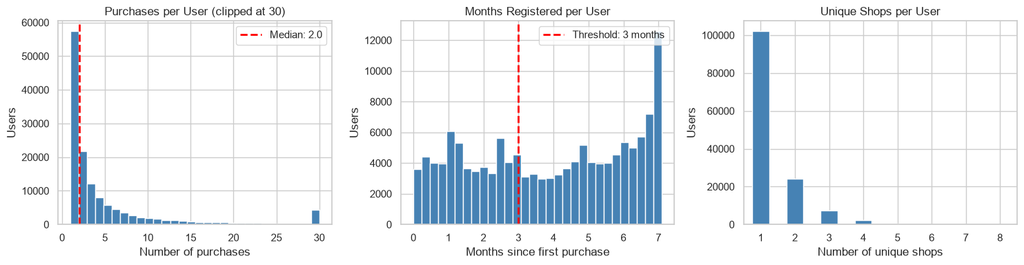

**Observations:**

- Most users have very few purchases. The distribution is heavily right-skewed with a median of just 2. A simple purchase count is not enough to define loyalty; we need a rate normalised by how long the user has been registered.
- Users are spread fairly evenly across registration tenures (0-7 months), but a large chunk joined recently without enough time to demonstrate loyalty. This motivates a minimum registration requirement before we classify anyone.
- 75% of users have only ever bought from one shop. This is a critical finding: a user buying frequently at one shop may be loyal to that merchant, not to Spendy. Shop diversity must be part of our loyalty definition.

## 2. Defining a Loyal Customer

Loyalty here means loyalty to Spendy as a platform, not just being a heavy user of one particular merchant who happens to offer Spendy as a payment option. The goal is to identify customers who have genuinely chosen Spendy, spend consistently, and keep coming back over time.

To get there, five components are defined below, each one grounded in the data. The first four are hard requirements that every loyal customer must meet: frequency, spend, recency, and a minimum registration period. The fifth is a platform loyalty check, where a customer can qualify through either of two routes; purchasing across multiple merchants, or demonstrating sustained activity over nearly the entire observation window. A customer must satisfy all four hard requirements and at least one of the two platform loyalty routes to be classified as loyal.

> **Note on pre-existing users:** ~47% of users have no `first_purchase=True` flag, meaning they joined before the dataset window (June 2020). Their true join date is unknown so tenure is measured from June 1, 2020, which slightly understates it and inflates their rates. This is acceptable for the loyalty definition in Section 2 since more data is better. The ML model in Section 4 avoids this entirely by using only new users.

### 2.1 Purchase Frequency

Frequency is measured as purchases per month rather than a raw count, so that customers with different registration tenures are compared on the same footing. The distribution below is used to find a threshold that separates genuinely regular users from occasional ones.

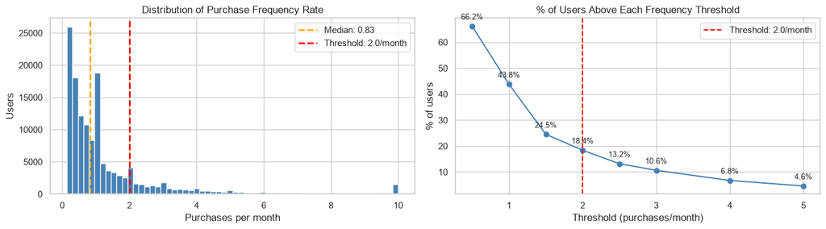

**Finding:** Most users buy less than once a month. The distribution is heavily right-skewed with a natural cluster at 1.0 (once/month users) and a clear elbow in the curve between 1.5 and 2.0.

**Decision: frequency >= 2 purchases/month.**  
The elbow between 1.5 and 2.0 marks a natural break in the distribution. Below it, users are buying once a month or less, which is more consistent with occasional use than a habit. At 2 purchases per month, there is enough regularity to suggest the customer is actively choosing Spendy rather than just stumbling into it.

### 2.2 Monthly Spend

Spend is measured as total spend per month, normalised by tenure for the same reason as frequency. The threshold here is meant to capture customers who are spending at a level that meaningfully contributes to platform revenue, not just making small or incidental transactions.

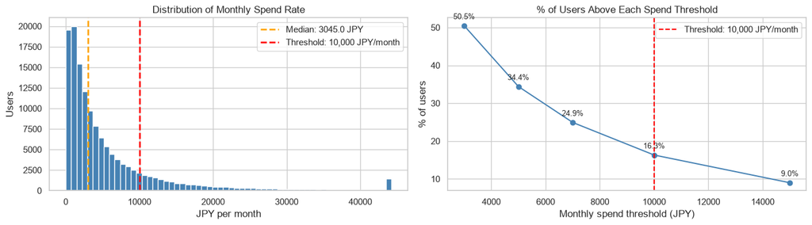

**Finding:** Median monthly spend is around 3,000 JPY and the mean sits around 6,000 JPY. The distribution is heavily right-skewed with most users spending very little per month.

**Decision: Monthly spend >= 10,000 JPY.**  
The 10,000 JPY mark sits clearly above the mean and captures the top ~16% of users. Below this, spend levels are low enough that they could easily reflect occasional or one-off purchases rather than consistent platform usage. At 10,000 JPY per month, the customer is spending at a level that is actually meaningful to the business.

### 2.3 Platform Loyalty Evidence

This is the component that separates loyalty to Spendy from loyalty to a single merchant. A customer who buys repeatedly at one shop might just be using Spendy because their favourite store happens to offer it, not because they have chosen Spendy as their preferred payment platform. The goal here is to find evidence that the customer's relationship is with Spendy itself.

There are two different ways a customer can demonstrate this. The first is through breadth: if a customer has purchased across at least two different merchants, they have actively brought Spendy to a new context. They did not have to do that. The second is through depth: if a customer has been active in at least 6 out of the 7 available months in the dataset, they have shown sustained, consistent engagement over nearly the entire observation window. That level of consistency, even at a single shop, is a strong signal that they keep coming back to Spendy by choice.

A customer needs to meet at least one of these two criteria. Either demonstrates genuine platform affinity; the paths are just different.

```
=== Shop Diversity — All Users ===
  >= 1 shop(s): 100.0 % of users
  >= 2 shop(s): 25.2 % of users
  >= 3 shop(s): 7.6 % of users
  >= 4 shop(s): 2.2 % of users
```

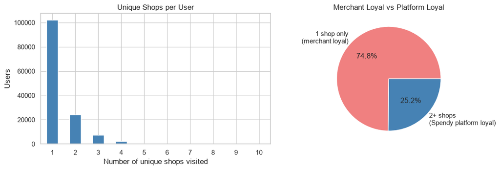

**Finding:** 75% of users have only ever purchased from a single shop. This alone would exclude most of the user base from any platform loyalty definition if shop diversity were treated as an absolute requirement.

**Decision, Path 1: Minimum 2 unique shops.**  
A customer who purchases at a second shop has deliberately chosen to use Spendy somewhere new. That is an active choice, not passive acceptance of whatever a single merchant offers. Two shops is a low bar deliberately: the signal here is the act of bringing Spendy to a new context, not how many times they have done it.

**Path 2: Sustained Activity**

The alternative evidence of platform loyalty is consistency over time. A customer who has been active in 6 out of 7 months has kept coming back to Spendy month after month, even if they only shop at one place. The distribution below shows how many users reach different levels of monthly activity, and the size of the group that qualifies only through this path (single shop, but consistently returning).

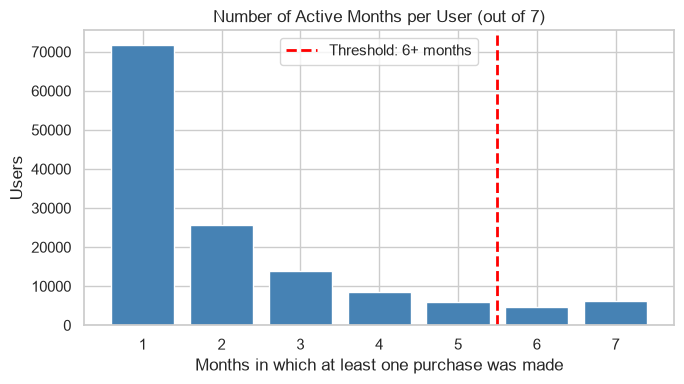

**Decision, Path 2: Active in 6 or more months.**  
Out of 7 available months in the dataset, 6 means the customer was present in almost every single one. This is a deliberately high bar: it is not enough to simply have been registered for a long time, the customer must have actually made at least one purchase each month. A single-shop customer who meets this standard has demonstrated the same consistency of platform engagement as a multi-shop customer, just expressed differently. Missing only one month across a 7-month window is a stronger loyalty signal than visiting two shops but only being active for 2 months.

### 2.4 Most Recent Purchase

A natural use case for a loyalty definition is that the business rewards loyal customers in terms of cashback, early access, promotions, or similar incentives. If that is the case, the recency component becomes critical: it is not primarily about flagging who is loyal, but about making sure inactive users do not keep receiving those benefits after they have stopped engaging. A user who qualified as loyal six months ago but has since gone quiet should not be treated the same as someone actively using Spendy today.

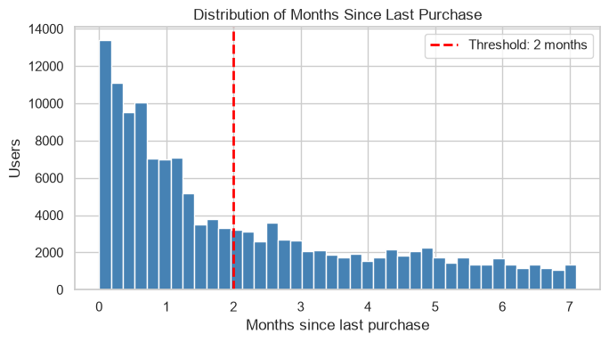

**Finding:** Most users have purchased recently. A 2-month cutoff gives a reasonable grace period. It does not penalise someone for skipping one month but does flag genuinely inactive users.

**Decision: Last purchase within 2 months.**  
Strict enough to keep the loyal label meaningful, lenient enough to allow for natural gaps in purchase cycles.

### 2.5 Minimum Registration Period

This component is justified by **business logic**, not a data threshold. The argument: a user who joins in December during the holiday season can rapidly clear the frequency and spend thresholds through Christmas gift purchases, then never use Spendy again. Without a minimum tenure gate, that user would be classified as loyal based on a single month of seasonal behaviour.

**Finding:** December joiners have at most 1 month of data. Users who buy frequently in December are likely doing so for Christmas gift purchases, not as a reflection of sustained platform usage. Without the minimum tenure gate, these users would be incorrectly labelled as loyal.

**Decision: Minimum 3 months registered.**  
This is a business constraint, not a percentile. Three months gives enough observation window to confirm that a user's behaviour is genuine and not a seasonal spike.

## 3. Applying the Loyalty Definition

All components are combined into a single binary label. The first four are hard requirements that every loyal customer must meet: purchase frequency of at least 2 per month, monthly spend of at least 10,000 JPY, a purchase within the last 2 months, and a minimum of 3 months registered. The fifth component is the platform loyalty check, where a customer qualifies by meeting either the shop diversity threshold (2+ unique merchants) or the sustained activity threshold (active in 6 or more of the 7 available months).

The loyal customer count is then tracked month by month, using only data available up to each cutoff, to simulate how this metric would behave in a live production environment.

```
Total users: 136830
Loyal customers: 6273 ( 4.6 % of all users)
```

```
  month  total_users  loyal_users  loyalty_rate
2020-06        30549            0          0.00
2020-07        49986            0          0.00
2020-08        67777          486          0.72
2020-09        81048         2577          3.18
2020-10        99585         3222          3.24
2020-11       118493         5115          4.32
2020-12       136455         6259          4.59
```

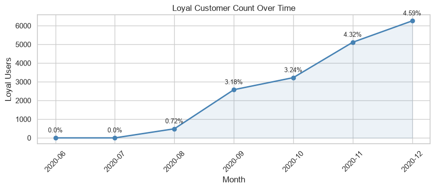

The definition used here is deliberately conservative, and the primary reason is the assumption that loyal customers will receive some form of monetary benefit, whether that is cashback, exclusive promotions, early access to new merchants, or similar rewards. When real money is attached to a label, the cost of a false positive goes up significantly. A customer who qualifies because of a single month of high spending in December, or because they happened to hit the frequency threshold briefly, should not be receiving the same benefits as someone who has been consistently active across six months.

This is why the thresholds are set where they are. Every customer who clears all the requirements has genuinely earned the label across multiple dimensions simultaneously. A loyalty rate of 4.6% in that context is not a sign that the definition is too strict, it is a sign that the label means something. A rewards programme that covers 30% of users is not a loyalty programme, it is a blanket discount scheme, and the business economics of the two are very different. If the reward structure is low-cost enough to justify broader reach, the thresholds can be revisited.

## 4. ML Model: Predicting Loyalty from First 2 Months

If a new customer's loyalty can be predicted early, marketing can act on it before the outcome is already known. Instead of treating all new customers the same, different communication strategies can be applied based on how likely a customer is to become loyal, right after their first two months on the platform.

The model takes only the first 2 months of a new customer's activity as input and predicts whether they will be loyal by Dec 31, evaluated using the same loyalty definition from Section 2: four hard requirements on frequency, spend, recency, and tenure, plus the OR condition on platform loyalty evidence (shop diversity or sustained activity). Only new users who joined by Sept 30 are included, so every user in the training set has had at least 3 months in the dataset before the label is assessed.

### 4.1 Feature Construction

We use each user's first 60 days of transactions as the input. This is the only information available at prediction time, after 2 months, marketing wants to act.

The five features map directly to the loyalty components defined in Section 2:

| Feature | Loyalty component |
| --- | --- |
| `freq_rate_2m` | Purchase frequency |
| `spend_rate_2m` | Monthly spend |
| `unique_shops_2m` | Platform loyalty vs merchant loyalty |
| `days_since_last_purchase_in_window` | Early recency signal: is engagement fading by end of month 2? |
| `spend_month_comparison` | Trend: is spend growing from month 1 to month 2? |

The minimum months registered component is handled at the setup level. It is a data quality gate, not a feature, so all users in the training data already satisfy it.

### 4.2 Label Construction

The loyalty label is evaluated at the **dataset end date (Dec 31)** for each eligible user, giving users the maximum observation window available. The label is taken directly from `user_stats['is_loyal']` computed in Section 2, which applies the full definition including the OR condition on platform loyalty. No recomputation is needed here; the label is already consistent with everything defined above.

### 4.3 Model Training

The model choice here is Random Forest, and the reasoning ties directly back to how the problem is set up.

The loyalty definition is built on hard thresholds, a user either crosses 2 purchases/month or they don't, either hits 10,000 JPY or they don't. That means the relationship between the features and the label is non-linear by design. Random Forest handles this naturally since it learns through decision tree splits, which essentially mirror the same threshold logic. A linear model like Logistic Regression would struggle here because it assumes a smooth relationship between features and the outcome, which isn't really the case.

The features also have a scale problem, `spend_rate_2m` can go up to ~50,000 JPY while `freq_rate_2m` sits between 0 and 10. On top of that, `spend_rate_2m` and `spend_month_comparison` are both derived from spend so they're correlated. These are exactly the kinds of issues that hurt Logistic Regression, and Random Forest doesn't care about either.

Probabilities are needed as the output, not just a class label, since the goal is to rank and segment customers. Random Forest's `predict_proba` works well for this, and the feature importances it gives are a bonus as they make it easy to explain what the model is actually picking up on.

`class_weight='balanced'` accounts for the class imbalance since most users are not loyal, and a stratified 80/20 split ensures the loyal-to-non-loyal ratio is preserved in both train and test sets.

### 4.4 Model Evaluation

ROC-AUC measures how well the model separates loyal from non-loyal users across all probability thresholds. For the classification report, the key metric to focus on is recall for the loyal class, missing a future loyal customer means a missed opportunity, which is more costly to the business than a false positive.

```
ROC-AUC: 0.912

              precision    recall  f1-score   support

   Not Loyal       0.98      0.97      0.98      6662
       Loyal       0.34      0.45      0.39       222

    accuracy                           0.95      6884
   macro avg       0.66      0.71      0.68      6884
weighted avg       0.96      0.95      0.96      6884
```

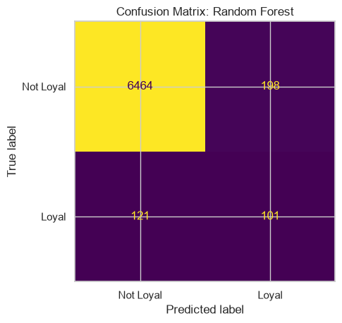

The class imbalance is the main factor shaping these results. Only 3.2% of users are loyal under the updated definition, so the model has very few positive examples to learn from. This is why precision on the loyal class is low at 0.34 — the model flags more users as likely loyal than actually turn out to be. `class_weight='balanced'` helps by giving the loyal class more weight during training, which improves recall to 0.45 at the cost of some precision. For this use case that is a reasonable trade-off since missing a genuinely loyal customer is more costly than occasionally acting on a false positive.

The ROC-AUC came in at 0.912, which is a strong result. With 96.8% of users being non-loyal, accuracy is a useless metric here since a model that simply predicts everyone as not loyal would score 96.8% while being completely useless. The ROC-AUC of 0.912 means the model correctly ranks a loyal user above a non-loyal one 91.2% of the time, which is what actually matters for segmentation.

Feature importance shows which signals the model relies on most. If the model is working correctly, `spend_rate_2m` and `freq_rate_2m` should rank near the top since they are the two most directly tied to the loyalty definition. An unexpected feature dominating would be a red flag for data leakage or a poorly specified feature.

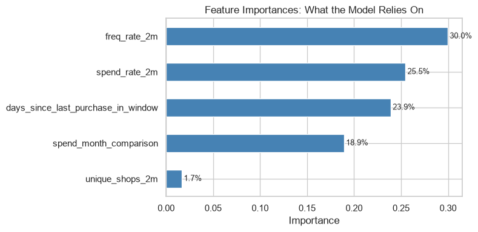

### 4.5 Segmentation: Business Output

The model's primary deliverable is a probability score for each new customer after their first 2 months. Customers are bucketed into three segments, each calling for a different marketing response.

| Segment | Suggested approach |
| --- | --- |
| **High likelihood** | Reinforce: reward early signals with exclusive offers or early access to build on existing momentum |
| **Medium likelihood** | Nudge: targeted campaigns to close the gap, spend incentives, merchant discovery prompts |
| **Low likelihood** | Re-engage or deprioritise: investigate whether there is a re-engagement trigger, or redirect budget to higher-value segments |

The model is applied to all eligible new users, not just the test set, to generate a loyalty probability score for each one. These scores are then bucketed into three segments based on where they fall between 0 and 1. Users below 0.33 go into Low likelihood, between 0.33 and 0.66 into Medium, and above 0.66 into High.

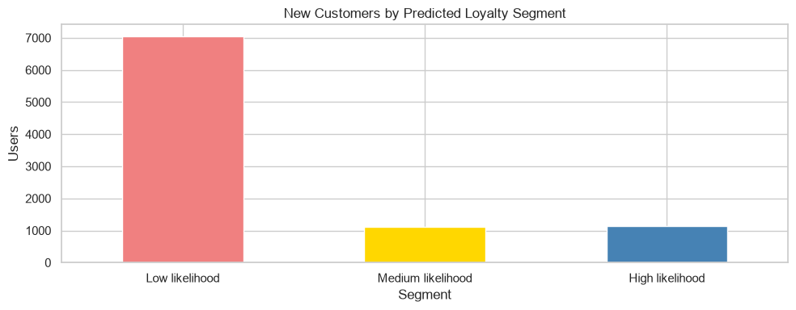

The average predicted probabilities back this up. Low averages 0.10, Medium 0.44, and High 0.95. The model is not hedging, it is producing confident scores at both ends, which is what makes the segmentation actionable. Marketing does not need to worry about borderline cases dominating the output.

## 5. Future Improvements

While the current model provides a strong baseline, several enhancements could further improve its performance and business value:

- **Longer observation period.**  
  Using a larger dataset spanning a full year or more would provide more examples of loyal customers and allow the loyalty definition to be validated over time.
- **Richer customer and transaction data.**  
  Additional information such as product or shop categories, customer demographics, promotion usage, or marketing campaign interactions could provide valuable signals that are not available in the current dataset.
- **Additional behavioural features.**  
  While shop diversity is observable within the first 60 days, sustained long-term engagement is not. Features that better capture consistency of early purchasing behaviour, such as purchase regularity or activity across both months, could help the model identify customers who later become loyal through sustained platform use.
- **Model refinement.**  
  Comparing Random Forest with other tree-based models, such as Gradient Boosting, and calibrating predicted probabilities could improve prediction quality and make customer scores more reliable.
- **Business-driven segmentation.**  
  Probability thresholds should ultimately be selected based on the expected ROI of different marketing campaigns rather than fixed values.

## 6. Conclusion

This analysis transformed a raw transaction log into a complete customer loyalty framework for Spendy.

**Section 2** established a practical definition of customer loyalty using five components grounded in data and business reasoning. Four are hard requirements that every loyal customer must satisfy: purchase frequency of at least two per month, monthly spend above 10,000 JPY, a purchase within the previous two months, and a minimum registration period of three months. The fifth is a platform loyalty check where a customer can qualify either by purchasing across at least two unique merchants (breadth) or by being active in at least six of the seven available months (depth). The OR condition ensures that genuinely engaged single-shop customers are not excluded purely on the basis of shop diversity, while still maintaining a high evidence bar for either path.

Overall, the analysis delivers both a transparent, business-driven definition of customer loyalty and a practical framework for identifying high-potential customers early in their lifecycle, enabling more targeted and effective marketing decisions.